# mixed model troubleshooting

# overview

## obligatory Tolstoy quote

- “all happy families are alike …”
- … but there are certainly *categories* of problems

## categories of warnings

- messages vs warnings vs errors
- convergence (numerical optimization questionable)
- singular fits (model is degenerate)
  - other forms of degeneracy (complete separation etc.)
- model diagnostics issues (model is inappropriate)

## messages vs warnings vs errors

- message = informational
- warning = potentially serious problem. Don’t ignore unless you understand it, and if so, then eliminate the warning as far upstream as possible (e.g. by changing options/settings; `suppressWarnings()` if that’s the only choice)
- error = so serious that R/package author can’t or won’t give you an answer (may be possible to override/work around …)

## load packages

```r
library(tidyverse)
library(broom.mixed)
library(lme4)
library(blme)
library(glmmTMB)
library(Matrix)
```

# convergence problems

## non-positive-definite Hessians

- what does this mean?
- modern mixed-model software does some form of non-linear optimization
  - sometimes just the covariance parameters, sometimes fixed + covariance parameters
  - (random-effects parameters are profiled out or estimated in an internal loop)
- at the optimum we should have a gradient of zero and a **positive definite** Hessian

## Hessian

$$\left(
\begin{array}{cccc}
\frac{\partial^2 L}{\partial \beta_{1}^2} & \frac{\partial^2
L}{\partial \beta_{1} \partial \beta_{2}} & \frac{\partial^2
L}{\partial \beta_{1} \partial \beta_{3}} & \ldots \\
\frac{\partial^2 L}{\partial \beta_{2} \partial \beta_{1}} &
\frac{\partial^2 L}{\partial \beta_{2}^2} & \frac{\partial^2
L}{\partial \beta_{2} \partial \beta_{3}} & \ldots \\
\frac{\partial^2 L}{\partial \beta_{3} \partial \beta_{1}} &
\frac{\partial^2 L}{\partial \beta_{3} \partial \beta_{2}} &
\frac{\partial^2 L}{\partial \beta_{3}^2} & \ldots \\
\vdots & \vdots & \vdots & \ddots
\end{array}
\right)$$

- eigenvalues of the Hessian give curvature in the principal directions (== eigenvectors)

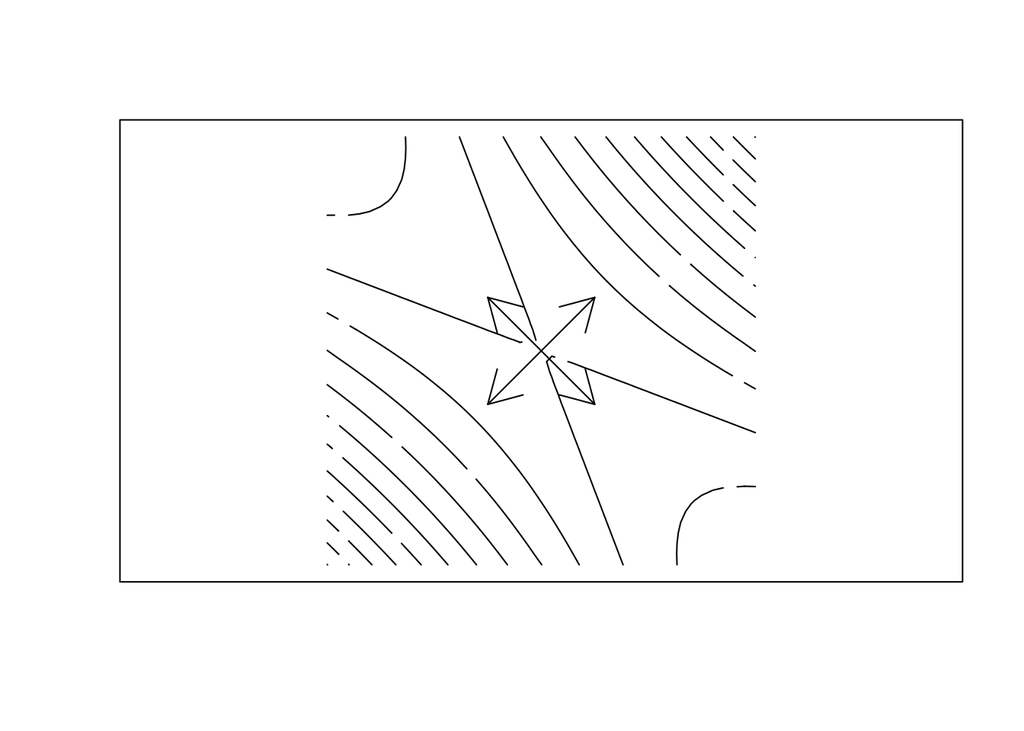

## solutions

- double-check the model definition and data
  - one random effect per observation (when the conditional distribution has a scale parameter)
  - all observations in a cluster have the same response value (e.g. [here](https://stackoverflow.com/a/53053309/190277))
  - etc.
- scale and center predictor variables (improves stability)
- general advice in Bolker *et al.* 2013<sup>1</sup> *may* be useful
- extract Hessian and see *which* eigenvector(s) is/are associated with the minimal eigenvalue(s)
  - extracting Hessian often requires some digging, e.g. `model@optinfo$derivs` (`lme4`) or `model$sdr$cov.fixed` (`glmmTMB`))

## more examples

- many GLMM parameters have a *bounded domain*
  - variances/standard deviations/dispersion parameters (0 to $\infty$)
  - probabilities (0 to 1)
- the easiest way to handle bounded optimization is to fit a *transformed*, unconstrained version of the parameter
  - log (variance, SD, ratios thereof, odds ratios)
  - logit/log-odds (probabilities)
- problems when the estimate is actually on the boundary of the original domain (transformed parameter $\to \pm \infty$)
- different packages handle this in different ways

## example: negative binomial dispersion

- NBinom can only handle *overdispersion*, not equi- or underdispersion
- example:

```r
set.seed(102)
dd <- data.frame(x = rpois(1000, lambda = 2))
m1 <- MASS::glm.nb(x ~ 1, data = dd)
environment(m1$family$variance)$.Theta
```

[output not shown]

- **solutions**
  - ignore it
  - revert to Poisson model
  - use a *quasi-likelihood* model (fit Poisson, then adjust SEs etc.)
  - use a distribution that allows underdispersion: (glmmTMB) `genpois`, `compois`, or an *ordinal* model

## example: non-zero-inflated models

- *zero-inflation* models fit a finite mixture of “structural” and “sampling” zeros
- “many zeros does not mean zero inflation”<sup>2</sup>
- log-odds(0) $\to -\infty$
- similar to NB case

## `lme4` convergence warnings

## a specific (problematic!) case

- extra check on top of optimizer-based convergence checks
- many false positives

## diagnosing convergence warnings

- `allFit`
- are parameters close enough?
- what is the distribution of negative log-likelihoods?
- which parameters are unstable?

```r
library(lme4)
source("R/conv_ex.R")
model1 <- lmer(eval~1 + group*(emint_n + grade_n) + (1 + grade_n+emint_n|class), data=dd)
```

Scaling (autoscaling is [on the list for lme4](https://github.com/lme4/lme4/issues/731)) …

```r
double_cols <- sapply(dd, is.double)
dd_sc <- dd
dd_sc[double_cols] <- sapply(dd[double_cols], \(x) drop(scale(x)))
model2 <- update(model1, data =  dd_sc)
```

```r
library(broom.mixed) ## for tidy()
library(ggplot2)
source("R/allFit_utils.R")
aa <- allFit(model1)
```

```
## bobyqa : [OK]
## Nelder_Mead : [OK]
## nlminbwrap :
```

```
## boundary (singular) fit: see help('isSingular')
```

```
## [OK]
## nmkbw :
```

```
## [OK]
## optimx.L-BFGS-B : [OK]
## nloptwrap.NLOPT_LN_NELDERMEAD : [OK]
## nloptwrap.NLOPT_LN_BOBYQA :
```

```
## [OK]
```

```r
tt <- tidy(aa)
```

Check log-likelihoods: do most or all optimizers agree?

```r
glance_allfit_NLL(aa)
```

```
## # A tibble: 7 × 2
##   optimizer                          NLL_rel
##   <chr>                                <dbl>
## 1 bobyqa                        0
## 2 nloptwrap.NLOPT_LN_NELDERMEAD 0.0000000207
## 3 Nelder_Mead                   0.0000000284
## 4 optimx.L-BFGS-B               0.000000209
## 5 nloptwrap.NLOPT_LN_BOBYQA     0.000000591
## 6 nlminbwrap                    1.14
## 7 nmkbw                         2.50
```

Run convergence check by hand:

```r
checkConv(model1@optinfo$derivs, model1@optinfo$val, lmerControl()$checkConv, model1@lower)
```

```
## $code
## [1] -1
##
## $messages
## [1] "Model failed to converge with max|grad| = 0.00229598 (tol = 0.002, component 1)"
```

(in this case it is the *scaled* gradient that fails the test).

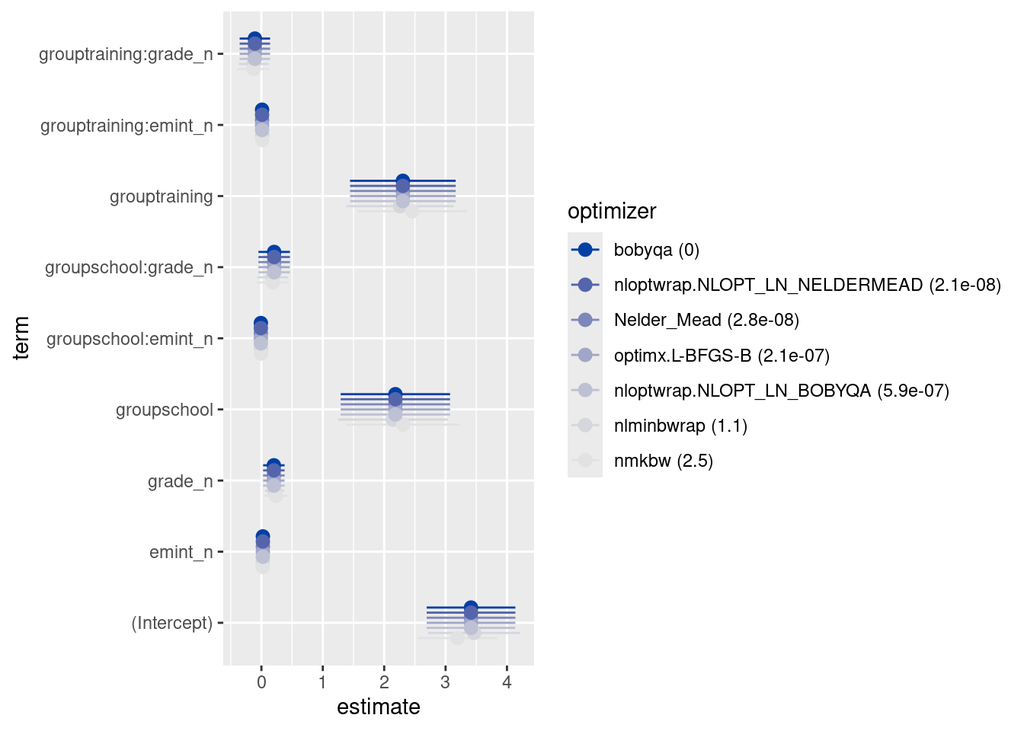

```r
plot_allfit(aa) + theme_set(theme_bw())
```

Check random effect components (may or may not be of interest):

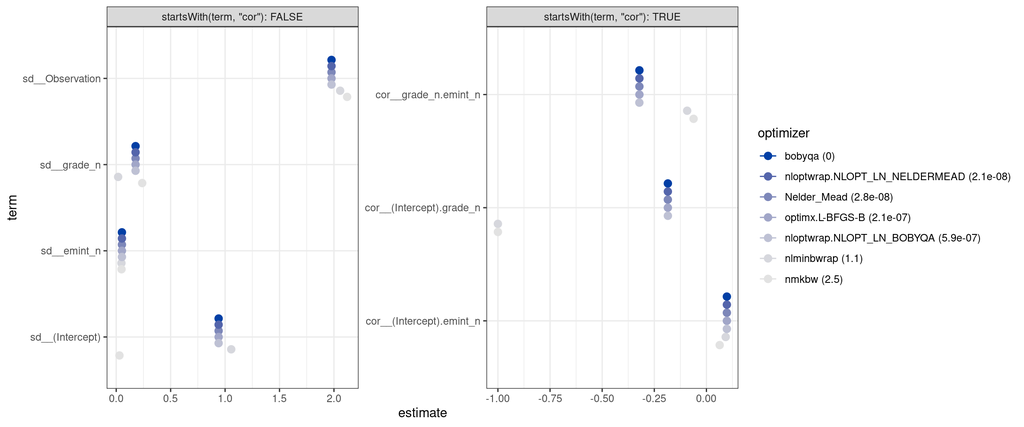

```r
plot_allfit(aa, keep_effects = "ran_pars")
```

## singular fits

```r
simfun <- function() {
    dd <- expand.grid(f = factor(1:3), rep = 1:10)
    dd$y <- suppressMessages(simulate(~ 1 + (1|f),
                     newdata = dd,
                     newparams = list(beta = 0, theta = 0.1, sigma = 1),
                     family = gaussian))[[1]]
    m <- lmer(y ~ 1 + (1 | f), data = dd,
              control = lmerControl(calc.derivs=FALSE, check.conv.singular = "ignore"))
    getME(m, "theta")
}
simfun()
```

```
## f.(Intercept)
##             0
```

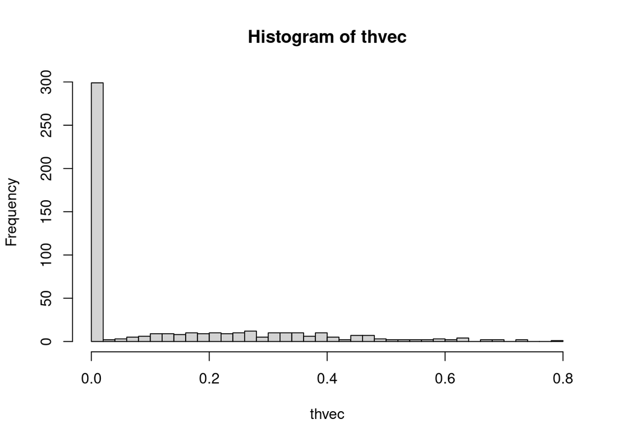

```r
set.seed(101)
thvec <- replicate(500, simfun())
hist(thvec, breaks = 50)
```

```r
library(lme4)
data(Orthodont,package="nlme")
Orthodont$nsex <- as.numeric(Orthodont$Sex=="Male")
Orthodont$nsexage <- with(Orthodont, nsex*age)
m1 <- lmer(distance ~ age + (age|Subject) + (0+nsex|Subject),
           start = c(1.8,-0.1,0.14, 0.5),
           ##(0 + nsexage|Subject),
           data=Orthodont)
```

```
## boundary (singular) fit: see help('isSingular')
```

```r
VarCorr(m1)
```

```
##  Groups    Name        Std.Dev.   Corr
##  Subject   (Intercept) 2.3270e+00
##            age         2.2643e-01 -0.609
##  Subject.1 nsex        6.9976e-05
##  Residual              1.3100e+00
```

```r
rePCA(m1)
```

```
## $Subject
## Standard deviations (1, .., p=3):
## [1] 1.7794421974 0.1368062328 0.0000534153
##
## Rotation (n x k) = (3 x 3):
##             [,1]       [,2] [,3]
## [1,] -0.99822608 0.05953739    0
## [2,]  0.05953739 0.99822608    0
## [3,]  0.00000000 0.00000000    1
##
## attr(,"class")
## [1] "prcomplist"
```

```r
library(nlme)
m2 <- lme(distance ~ age, random = ~age|Subject,
    data = Orthodont,
    weights = varIdent(form = ~1|Sex))
library(glmmTMB)
m3 <- glmmTMB(distance ~ age + (age|Subject),
              dispformula = ~Sex,
              REML = TRUE,
              data = Orthodont)
exp(fixef(m3)$disp)
```

```
## (Intercept)   SexFemale
##    1.645261    0.404098
```

```r
logLik(m3)
```

```
## 'log Lik.' -210.8233 (df=7)
```

## model simplification

- drop terms, e.g. correlation between slopes and intercepts<sup>5</sup>
- (should probably center continuous covariates first)
- Matuschek *et al*<sup>6</sup> say you should be dropping terms anyway
- drop correlations (e.g. `(f||g)` or `diag(f|g)`
- reduced-rank models (`glmmTMB` does *factor analytic* models, e.g. `rr(f1*f2|g, d = 5)`; or `gllvm` package)
- `buildmer` package (??)

## model simplication<sup>7</sup>

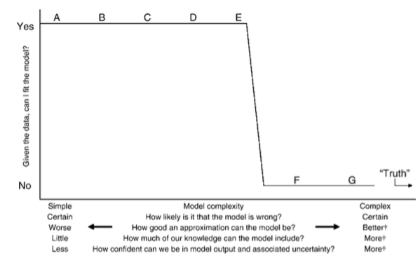

```r
include_graphics("pix/uriarte.png")
```

## regularization

- `blme`: assign priors, do maximum *a posteriori* estimation
  - default for RE terms: SD $\sim$ Gamma(shape = 2.5, rate = 0)<sup>8</sup>
- priors in `glmmTMB` (new)
- priors in Bayesian pkgs (of course) `MCMCglmm`, `brms`, `rstanarm`

## complete separation (GLM(M)-specific)

- Bernoulli data with 0/1 separation, count data with 0/positive separation
- Firth regression; add priors

## example (from glmmTMB vignette)

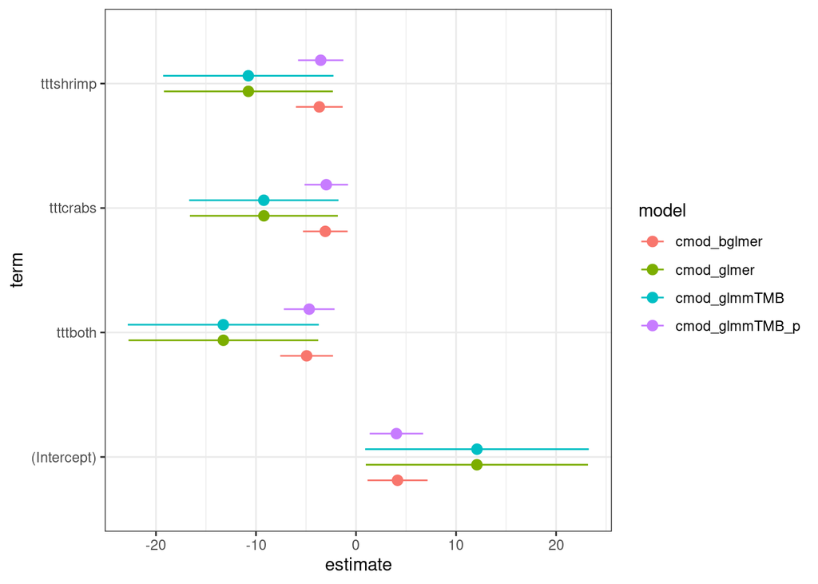

```r
load("data/culcita.RData")
cdatx <- culcita_dat[-20,]
form <- predation~ttt+(1|block)
cmod_glmer <- glmer(form, data=cdatx, family=binomial)
cmod_glmmTMB <- glmmTMB(form, data=cdatx, family=binomial)
cmod_bglmer <- bglmer(form, data=cdatx, family=binomial,
                    fixef.prior = normal(cov = diag(9,4)))
cprior <- data.frame(prior = rep("normal(0,3)", 2),
                     class = rep("beta", 2),
                     coef = c("(Intercept)", ""))
cmod_glmmTMB_p <- update(cmod_glmmTMB, priors = cprior)
tt <- (tibble::lst(cmod_glmer, cmod_glmmTMB, cmod_bglmer, cmod_glmmTMB_p)
    |> purrr::map_dfr(~ tidy(., effects = "fixed"), .id = "model")
)
ggplot(tt, aes(x = estimate, y = term, colour = model)) +
       geom_pointrange(aes(xmin = estimate - 2*std.error,
                           xmax = estimate + 2*std.error),
                       position = position_dodge(width = 0.5))
```

1.

Bolker, B. M. *et al.* [Strategies for fitting nonlinear ecological models in R, AD Model Builder, and BUGS](https://doi.org/10.1111/2041-210X.12044). *Methods in Ecology and Evolution* **4**, 501–512 (2013).

2.

Warton, D. I. [Many zeros does not mean zero inflation: Comparing the goodness-of-fit of parametric models to multivariate abundance data](https://doi.org/10.1002/env.702). *Environmetrics* **16**, 275–289 (2005).

3.

Pryseley, A., Tchonlafi, C., Verbeke, G. & Molenberghs, G. Estimating negative variance components from Gaussian and non-Gaussian data: A mixed models approach. *Computational Statistics & Data Analysis* **55**, 1071–1085 (2011).

4.

Bridge, H., Morgan, K. E. & Frost, C. [Negative variance components and intercept-slope correlations greater than one in magnitude: How do such ‘non-regular’ random intercept and slope models arise, and what should be done when they do?](https://doi.org/10.1002/sim.10070) *Statistics in Medicine* **n/a**, (2024).

5.

Barr, D. J., Levy, R., Scheepers, C. & Tily, H. J. [Random effects structure for confirmatory hypothesis testing: Keep it maximal](https://doi.org/10.1016/j.jml.2012.11.001). *Journal of Memory and Language* **68**, 255–278 (2013).

6.

Matuschek, H., Kliegl, R., Vasishth, S., Baayen, H. & Bates, D. [Balancing type I error and power in linear mixed models](https://doi.org/10.1016/j.jml.2017.01.001). *Journal of Memory and Language* **94**, 305–315 (2017).

7.

Uriarte, M. & Yackulic, C. B. Preaching to the unconverted. *Ecological Applications* **19**, 592–596 (2009).

8.

Chung, Y., Rabe-Hesketh, S., Dorie, V., Gelman, A. & Liu, J. A nondegenerate penalized likelihood estimator for variance parameters in multilevel models. *Psychometrika* 1–25 (2013) doi:10.1007/s11336-013-9328-2.